# Text Mining

Hailu Teju

January 6, 2018

### Data

The data set for this project is a collection of text documents consisting of news articles, blogs and twits.

### Goals

The tasks to be accomplished in this milestone report (towards developing a natural language processing - NLP - application) are:

*Exploratory analysis* - we perform a thorough exploratory analysis of the data, understand the number of lines and distribution of words in the corpora (the collections of documents).

*Understand frequencies of words and word pairs* - we build figures and tables to understand variations in the frequencies of words and combinations of words in the data.

### Read Files

First we read the three text sources, blog, news, and twitter, and create a `list` of the three documents.

The full data set

| text_source | line_count | word_count |
| --- | --- | --- |
| blog | 899288 | 37334441 |
| news | 77259 | 2643972 |
| twitter | 2360148 | 30373832 |

### Training set

Next, we create a training data set, consisting of about 5% of the original corpora of all the blog, news, and twitter documents, by using the `rbinom()` function.

### Basic summaries of the training set - line counts and word counts

The training set

| text_source | line_count | word_cound |
| --- | --- | --- |
| blog | 45016 | 1873247 |
| news | 3856 | 132757 |
| twitter | 117907 | 1518627 |

From the table above, we see that, for example, the blog sample data set has about 45,000 lines of text and over 1.87 million words.

### Preparing Corpora for word analysis

Next, the Corpora are put into their own Term Document Matrix and ready for further analysis. Words smaller than three characters are omitted.

### Most frequent words and n-grams

Exploring the distinct words and their frequencies in the blog, news, and twitter Term Document Matrices, we obtain the following results for the most frequent words in each corpus:

### Most frequent terms

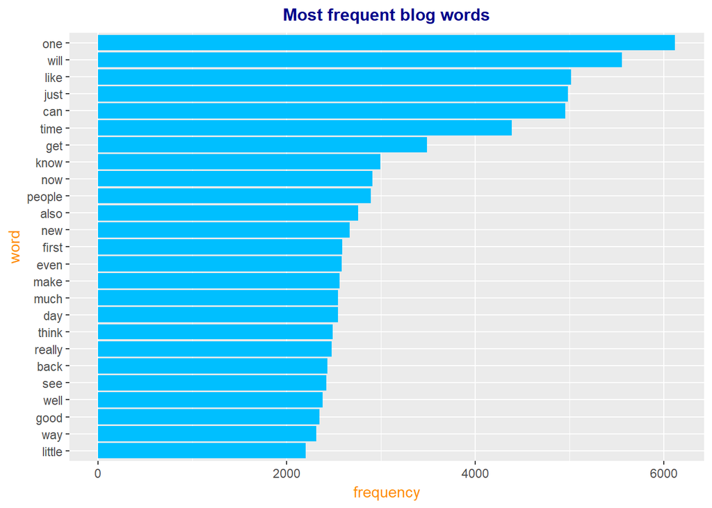

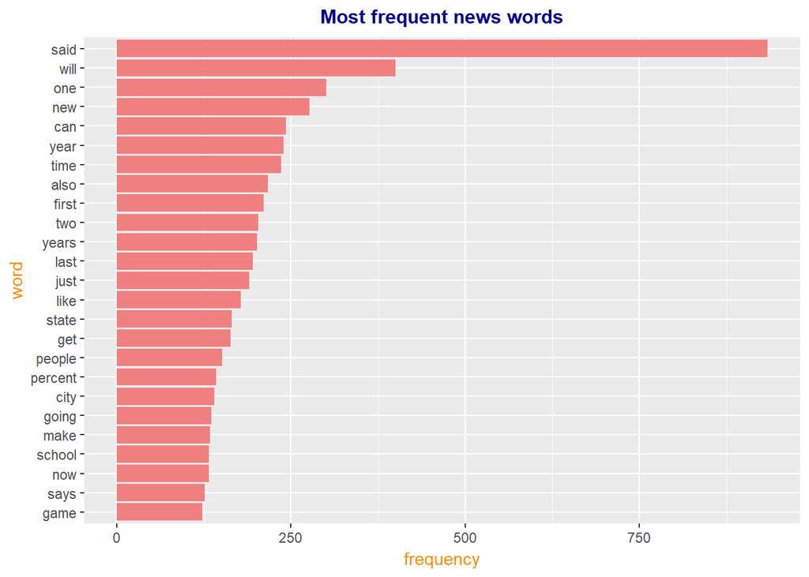

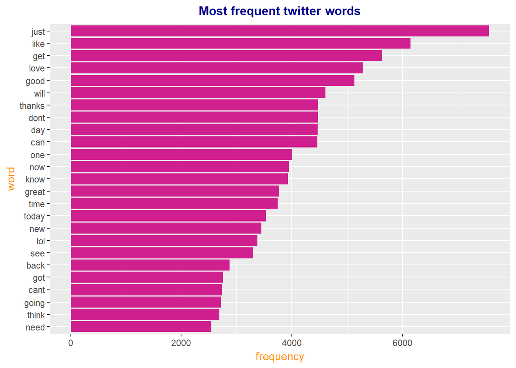

### Word cloud

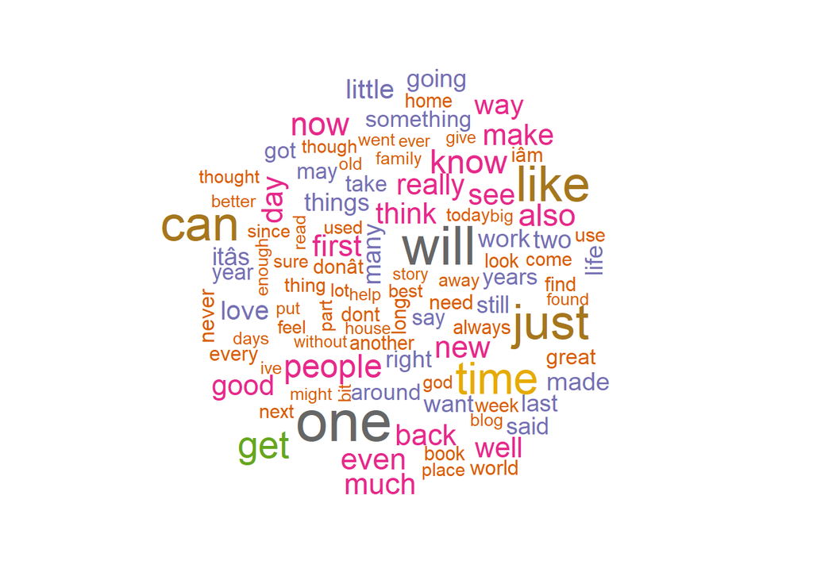

Top blog words

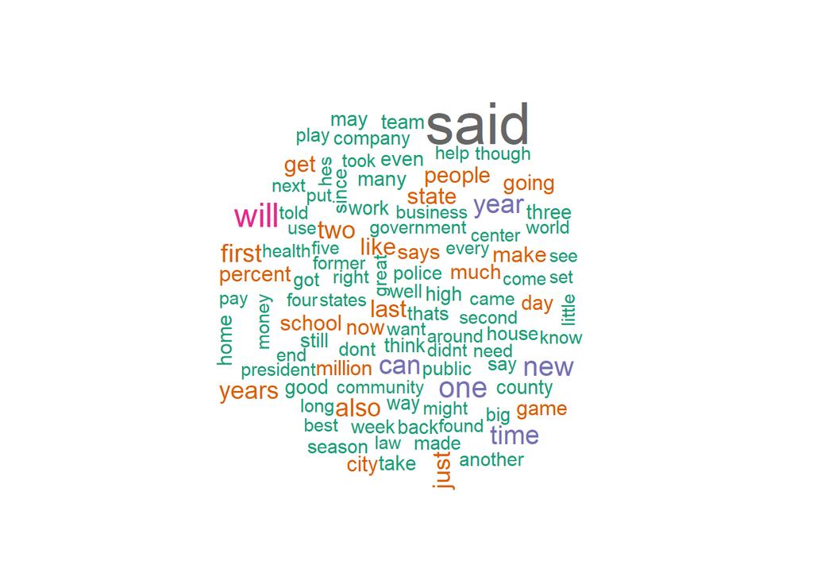

Top news words

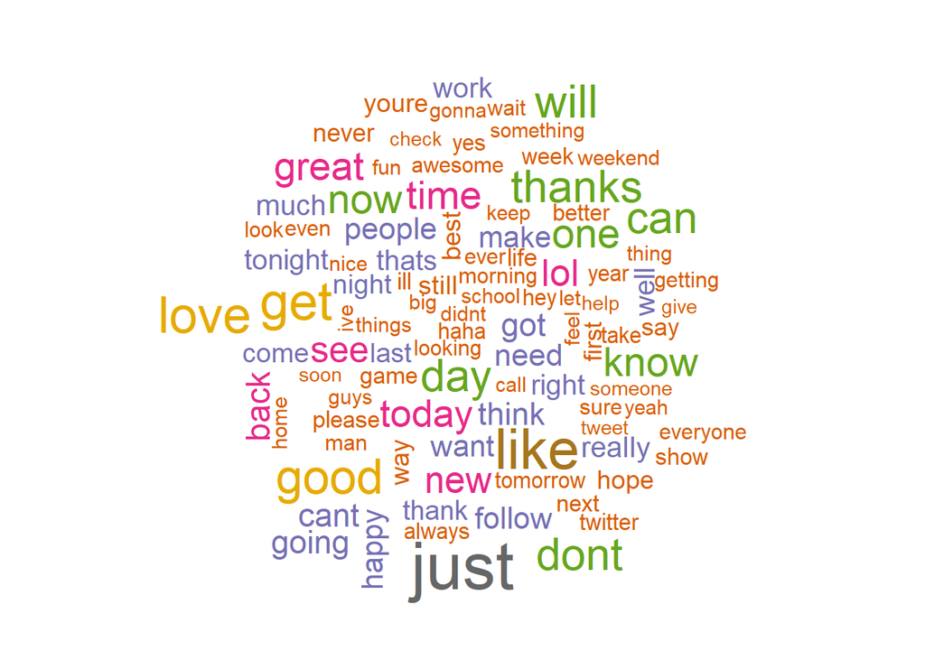

Top twitter words

### Bigrams and trigrams

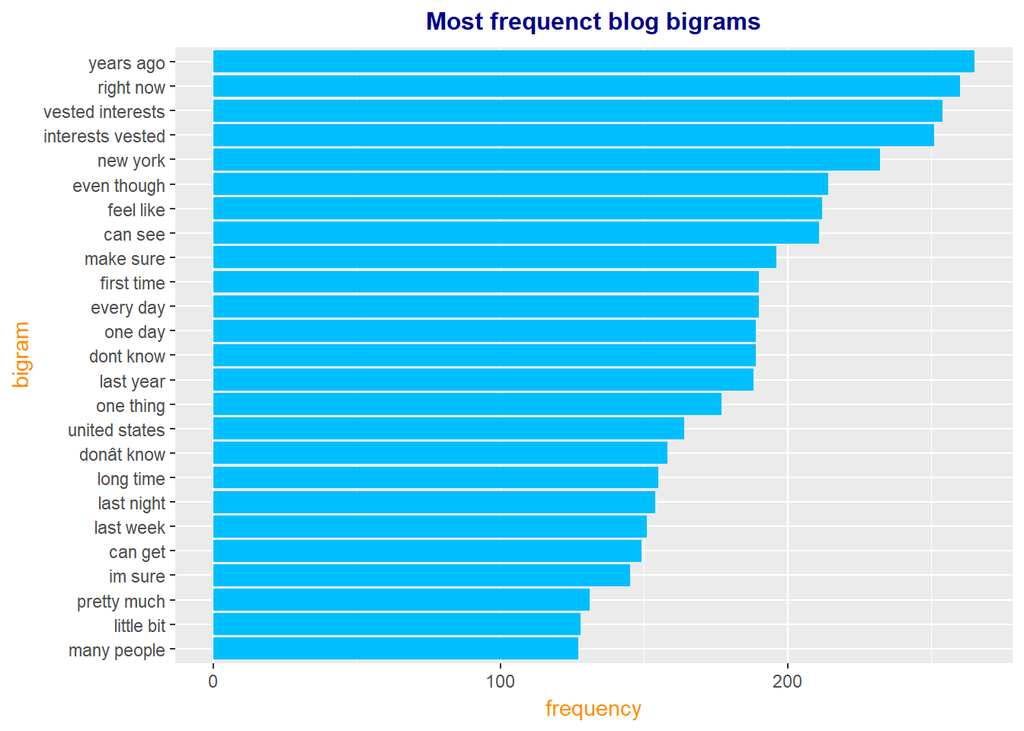

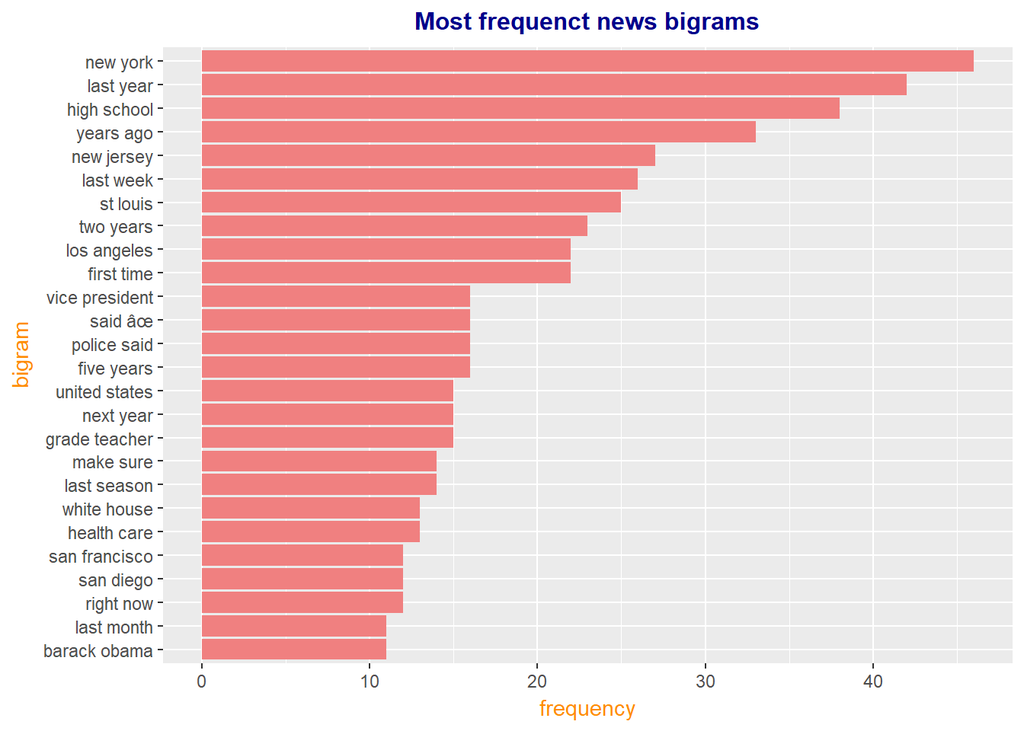

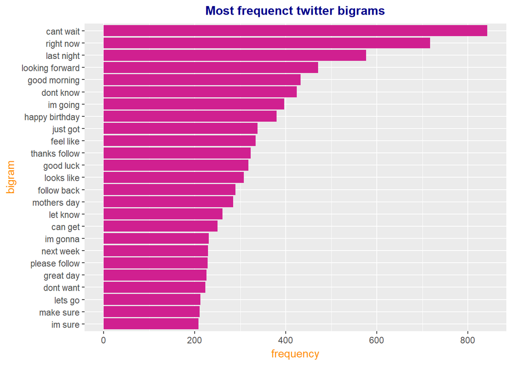

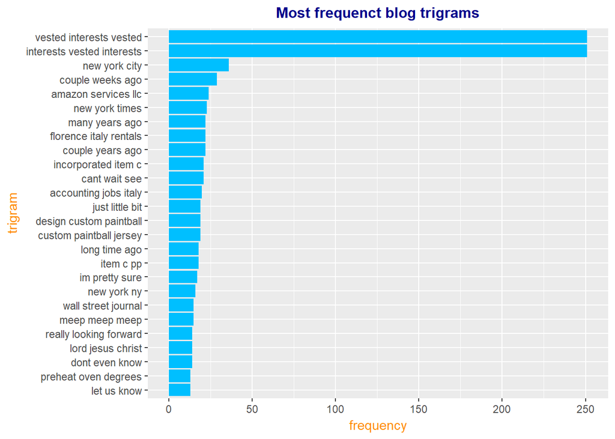

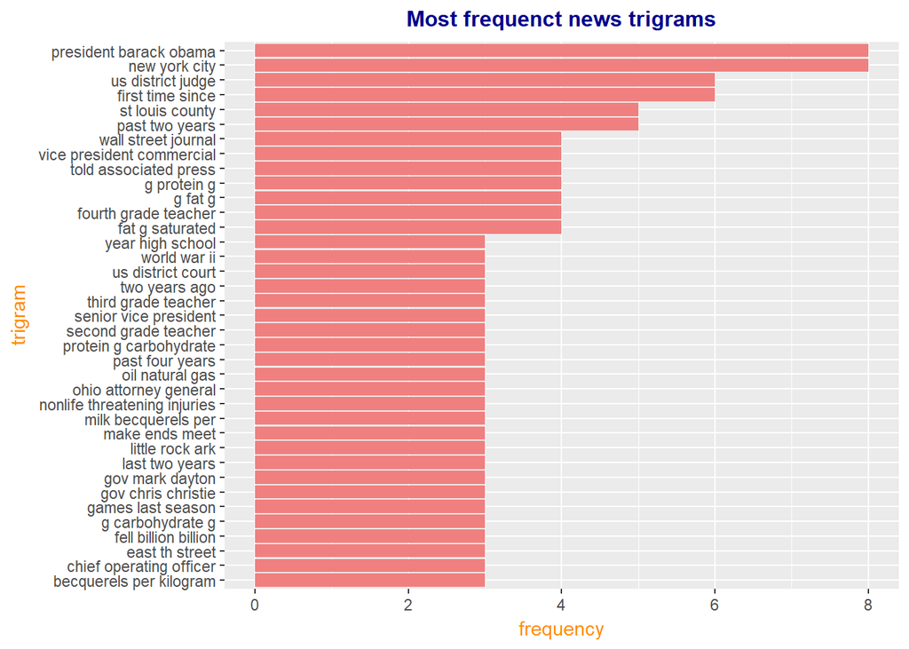

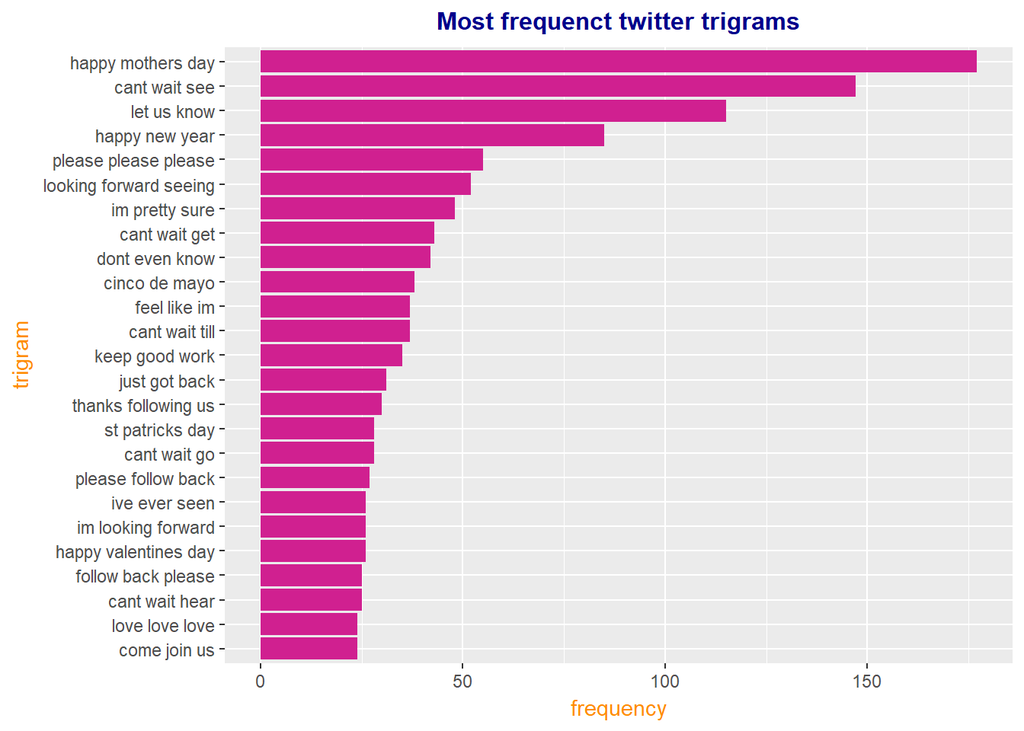

### Next step - ngrams and prediction algorithms

The next phase of this data science capstone project is to create a shinny application that predicts what the (most likely) next word is going to be when a user enters a word or phrase. The prediction algorithm is going to use the corpora discussed here and appropriate n-grams to rank the possible next words by frequency in the corpora.

### Appendix

```r
library(knitr)
library(dplyr)
library(tidyr)
library(tidytext)
library(tm)
library(RWeka)
library(stringr)
library(ggplot2)
library(readr)
library(RColorBrewer)
library(wordcloud)
library(kableExtra)


blog <- readLines("en_US.blogs.txt", skipNul = TRUE)
news <- readLines("en_US.news.txt", skipNul = TRUE)
twitter <- readLines("en_US.twitter.txt", skipNul = TRUE)


# Text sources are put into a list and traversed to calculate length and word count
wordCountFunc <- function(myList){sum(str_count(myList, "\\S+"))}

# Data frame to store counts
 df <- data.frame(textSource=c("blog", "news", "twitter"), lineCount=NA, wordCount = NA)


# Put corpora into a list
myList <- list(blog=blog, news=news, twitter=twitter)

# Get line count and word count for each corpus
df$lineCount <- sapply(myList, length)
df$wordCount <- sapply(myList, wordCountFunc)

df  %>% select(text_source=textSource, line_count=lineCount, word_count=wordCount) %>%
        #kable(format = "html", table.attr = "style='width:30%;'")
        kable(format="html", table.attr="style='color:darkblue;'", caption = "The full data set") %>%
        row_spec(0, background="lightblue") %>%
        kable_styling(full_width=F)

# Create a data frame for samples
sampleDF <- data.frame(textSource=c("blog", "news", "twitter"), lineCount=NA, wordCount=NA)

# Create a list of random variables
set.seed(135)
percent <- 0.05
randoms <- lapply(myList, function(x) rbinom(x, 1, percent))

# Create a new, empty list to store random selections
sampList <- list(blog=NA, news=NA, twitter=NA)

# Use the rbinom() function to traverse the orginal list and select a training set consisting of about 5% of the original data
for (i in 1:length(myList)) {
        sampList[[i]] <- myList[[i]][randoms[[i]]==1]
}
rm(myList)

# Get counts of sample list
sampleDF$lineCount <- sapply(sampList, length)
sampleDF$wordCount <- sapply(sampList, wordCountFunc)

sampleDF %>%
        select(text_source = textSource, line_count=lineCount, word_cound=wordCount)  %>%
        #kable(format = "html", table.attr = "style='width:30%;'")
        kable(format="html", table.attr="style='color:darkorange;'", caption = "The training set") %>%
        row_spec(0, background="wheat") %>%
        kable_styling(full_width=F)
rm(sampleDF)
# Helper functions
removeURL <- function(x) gsub("http:[[:alnum:]]*|https:[[:alnum:]]*", "", x)
removeHashTags <- function(x) gsub("#\\S+", "", x)
removeTwitterHandles <- function(x) gsub("@\\S+|[^[:alnum:] ]", "", x)
removeOther <- function(x) gsub("^\\w+[<].+[>][<].+[>]|[<].+[>]([<].+[>])?|[^[:ascii:]]", "", x, perl=T)

# Create corpus class
textCorpus <- VCorpus(VectorSource(sampList))

# Remove twitter handles, hashtags, numbers, punctuations, and other unicode characters
textCorpus <- tm_map(textCorpus, content_transformer(removeOther))
textCorpus <- tm_map(textCorpus, content_transformer(removeURL))
textCorpus <- tm_map(textCorpus, removeNumbers)
textCorpus <- tm_map(textCorpus, removePunctuation)

textCorpus["twitter"] <- tm_map(textCorpus["twitter"], content_transformer(removeHashTags))
textCorpus["twitter"] <- tm_map(textCorpus["twitter"], content_transformer(removeTwitterHandles))
textCorpus["news"] <- tm_map(textCorpus["news"], content_transformer(removeOther))

# Transform all terms to lowercase
textCorpus <- tm_map(textCorpus, content_transformer(tolower))

# Remove curse words and stopwords
textCorpus <- tm_map(textCorpus, removeWords, curseWords)
textCorpus <- tm_map(textCorpus, removeWords, stopwords("english"))

# Single tokenizers
twitterTdm <- TermDocumentMatrix(textCorpus["twitter"], control=list(wordLengths = c(3, Inf)))
newsTdm <- TermDocumentMatrix(textCorpus["news"], control=list(wordLengths = c(3, Inf)))

blogTdm <- TermDocumentMatrix(textCorpus["blog"], control=list(wordLengths = c(3, Inf)))


# Put word count from term-document matrices into data frames
freqBlog <- data.frame(word=blogTdm$dimnames$Terms, frequency = blogTdm$v)
freqNews <- data.frame(word=newsTdm$dimnames$Terms, frequency = newsTdm$v)
freqTwitter <- data.frame(word=twitterTdm$dimnames$Terms, frequency = twitterTdm$v)

# Reorder in descending order of frequency
freqBlog <- arrange(freqBlog, -frequency)
freqNews <- arrange(freqNews, -frequency)
freqTwitter <- arrange(freqTwitter, -frequency)
n <- 25L  # We'll be looking for top 25 words

topBlog <- freqBlog[1:n,]
topNews <- freqNews[1:n,]
topTwitter <- freqTwitter[1:n,]

# Reorder levels so charts plot in order of frequency
topBlog$word <- reorder(topBlog$word, topBlog$frequency)
topNews$word <- reorder(topNews$word, topNews$frequency)
topTwitter$word <- reorder(topTwitter$word, topTwitter$frequency)

# Plots
blogPlot <- ggplot(topBlog, aes(x=word, y=frequency)) +
        geom_col(fill="deepskyblue", show.legend = FALSE) +
        coord_flip() +
        labs(x="word", y="frequency", title="Most frequent blog words") +
        theme(plot.title=element_text(face="bold", colour="darkblue", size=12, hjust=0.5), axis.title.x=element_text(color="darkorange", size=11), axis.title.y=element_text(color="darkorange", size=11))
blogPlot

newsPlot <- ggplot(topNews, aes(x=word, y=frequency)) +
        geom_col(fill="lightcoral", show.legend = FALSE) +
        coord_flip() +
        labs(x="word", y="frequency", title="Most frequent news words") +
        theme(plot.title=element_text(face="bold", colour="darkblue", size=12, hjust=0.5), axis.title.x=element_text(color="darkorange", size=11), axis.title.y=element_text(color="darkorange", size=11))
newsPlot


twitterPlot <- ggplot(topTwitter, aes(x=word, y=frequency)) + geom_col(fill="violetred", show.legend = FALSE) +
        coord_flip() +
        labs(x="word", y="frequency", title="Most frequent twitter words") +
        theme(plot.title=element_text(face="bold", colour="darkblue", size=12, hjust=0.5), axis.title.x=element_text(color="darkorange", size=11), axis.title.y=element_text(color="darkorange", size=11))
twitterPlot
set.seed(8253)

wordcloud(freqBlog$word, freqBlog$frequency, max.words = 100, title.size=2.5, colors = brewer.pal(8, "Dark2"), scale = c(3,0.5))
set.seed(8262)
```

```r
wordcloud(freqNews$word, freqNews$frequency, max.words = 100, title.size=2.5, colors = brewer.pal(8, "Dark2"), scale = c(3,0.8))
set.seed(8271)

wordcloud(freqTwitter$word, freqTwitter$frequency, max.words = 100, title.size=2.5, colors = brewer.pal(8, "Dark2"), scale = c(3,0.6))

BigramTokenizer <- function(x) NGramTokenizer(x, Weka_control(min = 2, max = 2))
TrigramTokenizer <- function(x) NGramTokenizer(x, Weka_control(min = 3, max = 3))
FourgramTokenizer <- function(x) NGramTokenizer(x, Weka_control(min = 4, max = 4))


bigramBlogTdm <- TermDocumentMatrix(textCorpus["blog"],
                                    control = list(tokenize = BigramTokenizer,
                                                   wordLengths = c(3, Inf)))
freqBigramBlog <- data.frame(bigram = bigramBlogTdm$dimnames$Terms, frequency = bigramBlogTdm$v)
freqBigramBlog <- arrange(freqBigramBlog, -frequency)

bigramNewsTdm <- TermDocumentMatrix(textCorpus["news"],
                                    control = list(tokenize = BigramTokenizer,
                                                   wordLengths = c(3, Inf)))
freqBigramNews <- data.frame(bigram = bigramNewsTdm$dimnames$Terms, frequency = bigramNewsTdm$v)
freqBigramNews <- arrange(freqBigramNews, -frequency)

bigramTwitterTdm <- TermDocumentMatrix(textCorpus["twitter"],
                                       control = list(tokenize = BigramTokenizer,
                                                      wordLengths = c(3, Inf)))
freqBigramTwitter <- data.frame(bigram = bigramTwitterTdm$dimnames$Terms, frequency = bigramTwitterTdm$v)
freqBigramTwitter <- arrange(freqBigramTwitter, -frequency)

trigramBlogTdm <- TermDocumentMatrix(textCorpus["blog"],
                                     control = list(tokenize = TrigramTokenizer,
                                                    wordLengths = c(3, Inf)))
freqTrigramBlog <- data.frame(trigram = trigramBlogTdm$dimnames$Terms, frequency = trigramBlogTdm$v)
freqTrigramBlog <- arrange(freqTrigramBlog, -frequency)

trigramNewsTdm <- TermDocumentMatrix(textCorpus["news"],
                                     control = list(tokenize = TrigramTokenizer,
                                                    wordLengths = c(3, Inf)))
freqTrigramNews <- data.frame(trigram = trigramNewsTdm$dimnames$Terms, frequency = trigramNewsTdm$v)
freqTrigramNews <- arrange(freqTrigramNews, -frequency)

trigramTwitterTdm <- TermDocumentMatrix(textCorpus["twitter"],
                                        control = list(tokenize = TrigramTokenizer,
                                                       wordLengths = c(3, Inf)))
freqTrigramTwitter <- data.frame(trigram = trigramTwitterTdm$dimnames$Terms, frequency = trigramTwitterTdm$v)
freqTrigramTwitter <- arrange(freqTrigramTwitter, -frequency)


# Plots of bi- and tri-grams

(freqBigramBlog %>% top_n(25) %>% mutate(bigram=reorder(bigram, frequency)) %>%
                ggplot(aes(bigram, frequency)) +
                geom_col(fill="deepskyblue", show.legend = F) +
                coord_flip() +
                labs(x="bigram", y="frequency", title="Most frequenct blog bigrams") +
                theme(plot.title=element_text(face="bold", colour="darkblue", size=12, hjust=0.5), axis.title.x=element_text(color="darkorange", size=11), axis.title.y=element_text(color="darkorange", size=11)))

(freqBigramNews %>% top_n(25) %>% mutate(bigram=reorder(bigram, frequency)) %>%
                ggplot(aes(bigram, frequency)) +
                geom_col(fill="lightcoral", show.legend = F) +
                coord_flip() +
                labs(x="bigram", y="frequency", title="Most frequenct news bigrams") +
                theme(plot.title=element_text(face="bold", colour="darkblue", size=12, hjust=0.5), axis.title.x=element_text(color="darkorange", size=11), axis.title.y=element_text(color="darkorange", size=11)))

(freqBigramTwitter %>% top_n(25) %>% mutate(bigram=reorder(bigram, frequency)) %>%
                ggplot(aes(bigram, frequency)) +
                geom_col(fill="violetred", show.legend = F) +
                coord_flip() +
                labs(x="bigram", y="frequency", title="Most frequenct twitter bigrams") +
                theme(plot.title=element_text(face="bold", colour="darkblue", size=12, hjust=0.5), axis.title.x=element_text(color="darkorange", size=11), axis.title.y=element_text(color="darkorange", size=11)))

(freqTrigramBlog %>% top_n(25) %>% mutate(trigram=reorder(trigram, frequency)) %>%
                ggplot(aes(trigram, frequency)) +
                geom_col(fill="deepskyblue", show.legend = F) +
                coord_flip() +
                labs(x="trigram", y="frequency", title="Most frequenct blog trigrams") +
                theme(plot.title=element_text(face="bold", colour="darkblue", size=12, hjust=0.5), axis.title.x=element_text(color="darkorange", size=11), axis.title.y=element_text(color="darkorange", size=11)))

(freqTrigramNews %>% top_n(25) %>% mutate(trigram=reorder(trigram, frequency)) %>%
                ggplot(aes(trigram, frequency)) +
                geom_col(fill="lightcoral", show.legend = F) +
                coord_flip() +
                labs(x="trigram", y="frequency", title="Most frequenct news trigrams") +
                theme(plot.title=element_text(face="bold", colour="darkblue", size=12, hjust=0.5), axis.title.x=element_text(color="darkorange", size=11), axis.title.y=element_text(color="darkorange", size=11)))

(freqTrigramTwitter %>% top_n(25) %>% mutate(trigram=reorder(trigram, frequency)) %>%
                ggplot(aes(trigram, frequency)) +
                geom_col(fill="violetred", show.legend = F) +
                coord_flip() +
                labs(x="trigram", y="frequency", title="Most frequenct twitter trigrams") +
                theme(plot.title=element_text(face="bold", colour="darkblue", size=12, hjust=0.5), axis.title.x=element_text(color="darkorange", size=11), axis.title.y=element_text(color="darkorange", size=11)))
```